# Exploring Credit Risk for Lenders and Borrowers

Jessica Gorr

2/5/2025

## 2. Introduction

The purpose of this analysis is to look at some insights and interesting features of credit card risks for both the lender and borrowers. There have been no methods that describe how or where the the data was collected, so we will not take into account on how countries laws are applicable to lenders. The target variable is loan_status, which describes if a borrower has a defaulted loan. The dataset is composed by 32581 rows (observations) and 12 columns (variables), which are described below:

person_age (numerical): is the age of the person at the time of the loan.

person_income (numerical): is the yearly income of the person at the time of the loan.

person_home_ownership (categorical): is the type of ownership of the home.

person_emp_length (numerical): is the amount of time in years that person is employed.

loan_intent (categorical): is the aim of the loan.

loan_grade (categorical): is a classification system that involves assigning a quality score to a loan based on a borrower’s credit history, quality of the collateral, and the likelihood of repayment of the principal and interest.

loan_amnt (numerical): is the dimension of the loan taken.

loan_int_rate (numerical): is the interest paid for the loan.

loan_status (binary): is a dummy variable where 1 is default, 0 is not default.

loan_percent_income (numerical): is the ratio between the loan taken and the annual income.

cb_person_default_on_file (binary): answers whether the person has defaulted before.

cb_person_cred_hist_length (numerical): represents the number of years of personal history since the first loan taken from that person.

A public link to the data can be found here: https://www.kaggle.com/datasets/laotse/credit-risk-dataset

The tasks performed in this analysis are looking at different distribution of individual features and exploring relationships between features.Through this exploratory analysis all important observations, implications, and any actions performed will be explained. A quick example of the data is found below.

```r
library(dplyr)
library(reshape2)
library(tidyr)
library(ggplot2)
library(tibble)

#Load the sample data
credit_risk_dataset = read.csv("https://jessgorr01.github.io/STA551/sta552/project1/credit_risk_dataset.csv")


head(credit_risk_dataset)
```

```
##   person_age person_income person_home_ownership person_emp_length loan_intent
## 1         22         59000                  RENT               123    PERSONAL
## 2         21          9600                   OWN                 5   EDUCATION
## 3         25          9600              MORTGAGE                 1     MEDICAL
## 4         23         65500                  RENT                 4     MEDICAL
## 5         24         54400                  RENT                 8     MEDICAL
## 6         21          9900                   OWN                 2     VENTURE
##   loan_grade loan_amnt loan_int_rate loan_status loan_percent_income
## 1          D     35000         16.02           1                0.59
## 2          B      1000         11.14           0                0.10
## 3          C      5500         12.87           1                0.57
## 4          C     35000         15.23           1                0.53
## 5          C     35000         14.27           1                0.55
## 6          A      2500          7.14           1                0.25
##   cb_person_default_on_file cb_person_cred_hist_length
## 1                         Y                          3
## 2                         N                          2
## 3                         N                          3
## 4                         N                          2
## 5                         Y                          4
## 6                         N                          2
```

## 3. Distribution of Individual Features

### Cleaning and first looks

```r
#Transforming variables to factors
credit_risk_dataset$loan_status <- as.factor(credit_risk_dataset$loan_status)
credit_risk_dataset$person_home_ownership <- as.factor(credit_risk_dataset$person_home_ownership)
credit_risk_dataset$loan_intent <- as.factor(credit_risk_dataset$loan_intent)
credit_risk_dataset$loan_grade <- as.factor(credit_risk_dataset$loan_grade)
credit_risk_dataset$cb_person_default_on_file <- as.factor(credit_risk_dataset$cb_person_default_on_file)

glimpse(credit_risk_dataset) # more ordered
```

```
## Rows: 32,581
## Columns: 12
## $ person_age                 <int> 22, 21, 25, 23, 24, 21, 26, 24, 24, 21, 22,…
## $ person_income              <int> 59000, 9600, 9600, 65500, 54400, 9900, 7710…
## $ person_home_ownership      <fct> RENT, OWN, MORTGAGE, RENT, RENT, OWN, RENT,…
## $ person_emp_length          <dbl> 123, 5, 1, 4, 8, 2, 8, 5, 8, 6, 6, 2, 2, 4,…
## $ loan_intent                <fct> PERSONAL, EDUCATION, MEDICAL, MEDICAL, MEDI…
## $ loan_grade                 <fct> D, B, C, C, C, A, B, B, A, D, B, A, A, E, A…
## $ loan_amnt                  <int> 35000, 1000, 5500, 35000, 35000, 2500, 3500…
## $ loan_int_rate              <dbl> 16.02, 11.14, 12.87, 15.23, 14.27, 7.14, 12…
## $ loan_status                <fct> 1, 0, 1, 1, 1, 1, 1, 1, 1, 1, 1, 1, 1, 1, 0…
## $ loan_percent_income        <dbl> 0.59, 0.10, 0.57, 0.53, 0.55, 0.25, 0.45, 0…
## $ cb_person_default_on_file  <fct> Y, N, N, N, Y, N, N, N, N, N, N, N, N, N, N…
## $ cb_person_cred_hist_length <int> 3, 2, 3, 2, 4, 2, 3, 4, 2, 3, 4, 2, 2, 4, 4…
```

```r
#str(credit_risk_dataset)
```

The summary of our data, including missing values is below:

```r
summary(credit_risk_dataset)
```

```
##    person_age     person_income     person_home_ownership person_emp_length
##  Min.   : 20.00   Min.   :   4000   MORTGAGE:13444        Min.   :  0.00
##  1st Qu.: 23.00   1st Qu.:  38500   OTHER   :  107        1st Qu.:  2.00
##  Median : 26.00   Median :  55000   OWN     : 2584        Median :  4.00
##  Mean   : 27.73   Mean   :  66075   RENT    :16446        Mean   :  4.79
##  3rd Qu.: 30.00   3rd Qu.:  79200                         3rd Qu.:  7.00
##  Max.   :144.00   Max.   :6000000                         Max.   :123.00
##                                                           NA's   :895
##             loan_intent   loan_grade   loan_amnt     loan_int_rate
##  DEBTCONSOLIDATION:5212   A:10777    Min.   :  500   Min.   : 5.42
##  EDUCATION        :6453   B:10451    1st Qu.: 5000   1st Qu.: 7.90
##  HOMEIMPROVEMENT  :3605   C: 6458    Median : 8000   Median :10.99
##  MEDICAL          :6071   D: 3626    Mean   : 9589   Mean   :11.01
##  PERSONAL         :5521   E:  964    3rd Qu.:12200   3rd Qu.:13.47
##  VENTURE          :5719   F:  241    Max.   :35000   Max.   :23.22
##                           G:   64                    NA's   :3116
##  loan_status loan_percent_income cb_person_default_on_file
##  0:25473     Min.   :0.0000      N:26836
##  1: 7108     1st Qu.:0.0900      Y: 5745
##              Median :0.1500
##              Mean   :0.1702
##              3rd Qu.:0.2300
##              Max.   :0.8300
##
##  cb_person_cred_hist_length
##  Min.   : 2.000
##  1st Qu.: 3.000
##  Median : 4.000
##  Mean   : 5.804
##  3rd Qu.: 8.000
##  Max.   :30.000
##
```

Some quick insights that can be pulled from the summary of the data are:

1.person_age has a strange result: the max value is 144 which is unlikely to be true. 2.person_emp_length has 895 NAs 3.person_emp_length has a max value of 123 which is not possible. 4.loan_interest_rate has 3116 NAs 5.according to the data (loan_status), 21.82% (7108/32581) of people have defaulted, value that is quite high.

From these insights outliers can be identified. A plot below will focus one two we have potentally found above in our summary.

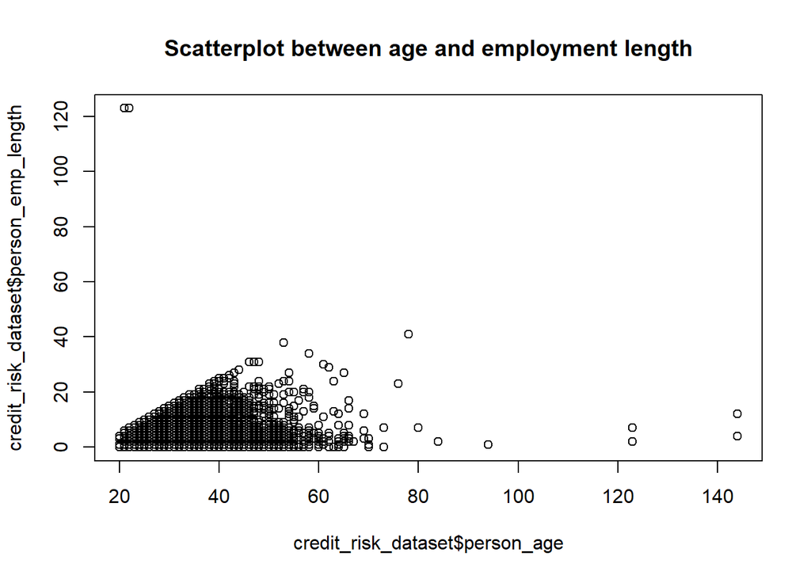

```r
plot(credit_risk_dataset$person_age, credit_risk_dataset$person_emp_length,  main = "Scatterplot between age and employment length")
```

Here it can be clearly seen that there are some issues on data by looking at outliers. It is impossible that two 20 years old have over 120 years of experience. Now illogical outliers must be removed and cleaned from the data before starting exploratory phase. This can be seen below:

```r
credit_risk <- credit_risk_dataset %>%
    filter(!is.na(person_emp_length)) %>%
    filter(!is.na(loan_int_rate)) %>%
    filter(person_age < 90) %>%
    filter(person_emp_length < 100)

summary(credit_risk)
```

```
##    person_age    person_income     person_home_ownership person_emp_length
##  Min.   :20.00   Min.   :   4000   MORTGAGE:11798        Min.   : 0.00
##  1st Qu.:23.00   1st Qu.:  39456   OTHER   :   94        1st Qu.: 2.00
##  Median :26.00   Median :  55900   OWN     : 2192        Median : 4.00
##  Mean   :27.71   Mean   :  66427   RENT    :14548        Mean   : 4.78
##  3rd Qu.:30.00   3rd Qu.:  80000                         3rd Qu.: 7.00
##  Max.   :84.00   Max.   :2039784                         Max.   :41.00
##
##             loan_intent   loan_grade   loan_amnt     loan_int_rate
##  DEBTCONSOLIDATION:4565   A:9401     Min.   :  500   Min.   : 5.42
##  EDUCATION        :5702   B:9149     1st Qu.: 5000   1st Qu.: 7.90
##  HOMEIMPROVEMENT  :3198   C:5697     Median : 8000   Median :10.99
##  MEDICAL          :5293   D:3247     Mean   : 9655   Mean   :11.04
##  PERSONAL         :4875   E: 870     3rd Qu.:12500   3rd Qu.:13.48
##  VENTURE          :4999   F: 209     Max.   :35000   Max.   :23.22
##                           G:  59
##  loan_status loan_percent_income cb_person_default_on_file
##  0:22430     Min.   :0.0000      N:23530
##  1: 6202     1st Qu.:0.0900      Y: 5102
##              Median :0.1500
##              Mean   :0.1695
##              3rd Qu.:0.2300
##              Max.   :0.8300
##
##  cb_person_cred_hist_length
##  Min.   : 2.000
##  1st Qu.: 3.000
##  Median : 4.000
##  Mean   : 5.794
##  3rd Qu.: 8.000
##  Max.   :30.000
##
```

### Univarite Analysis

All of our numerical features distributions can be seen below:

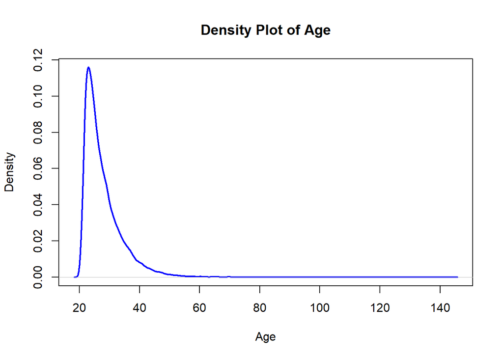

```r
# histogram showing the distribution of the duration variable
plot(density(credit_risk_dataset$person_age), main = "Density Plot of Age",
     xlab = "Age", ylab = "Density", col = "blue", lwd = 2)
```

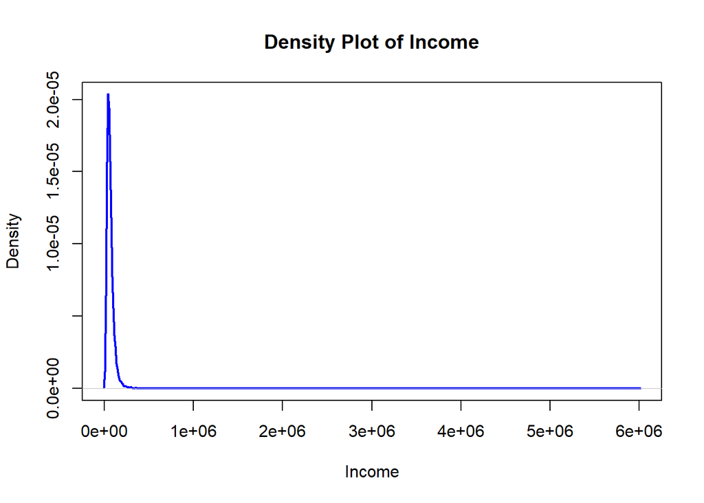

```r
plot(density(credit_risk_dataset$person_income), main = "Density Plot of Income",
     xlab = "Income", ylab = "Density", col = "blue", lwd = 2)
```

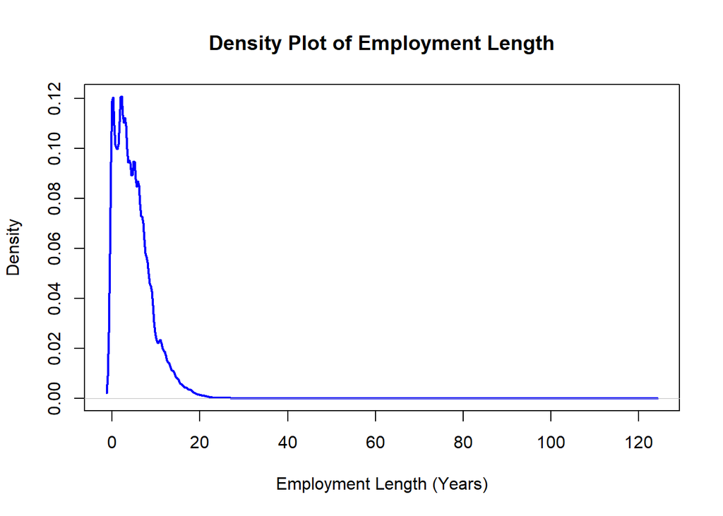

```r
plot(density(credit_risk_dataset$person_emp_length, na.rm = TRUE), main = "Density Plot of Employment Length",
     xlab = "Employment Length (Years)", ylab = "Density", col = "blue", lwd = 2)
```

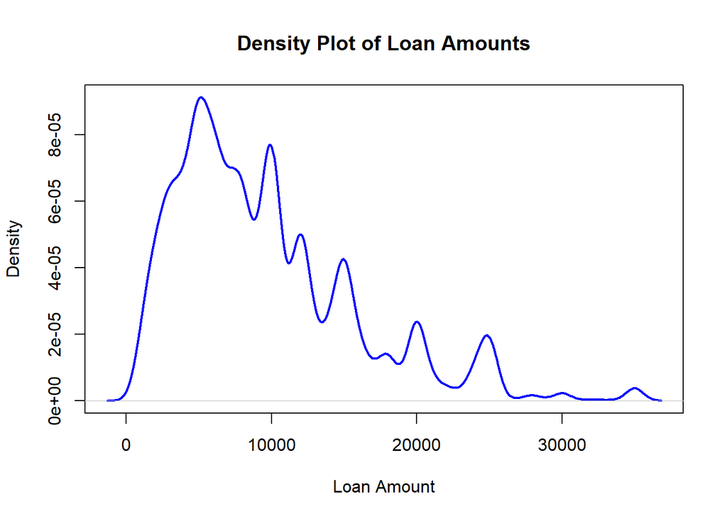

```r
plot(density(credit_risk_dataset$loan_amnt, na.rm = TRUE), main = "Density Plot of Loan Amounts",
     xlab = "Loan Amount", ylab = "Density", col = "blue", lwd = 2)
```

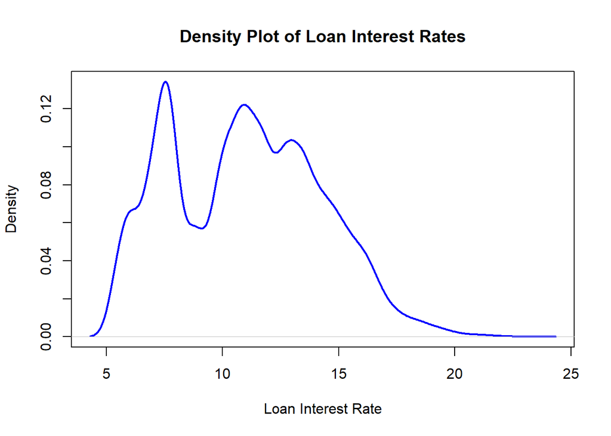

```r
plot(density(credit_risk_dataset$loan_int_rate, na.rm = TRUE), main = "Density Plot of Loan Interest Rates",
     xlab = "Loan Interest Rate", ylab = "Density", col = "blue", lwd = 2)
```

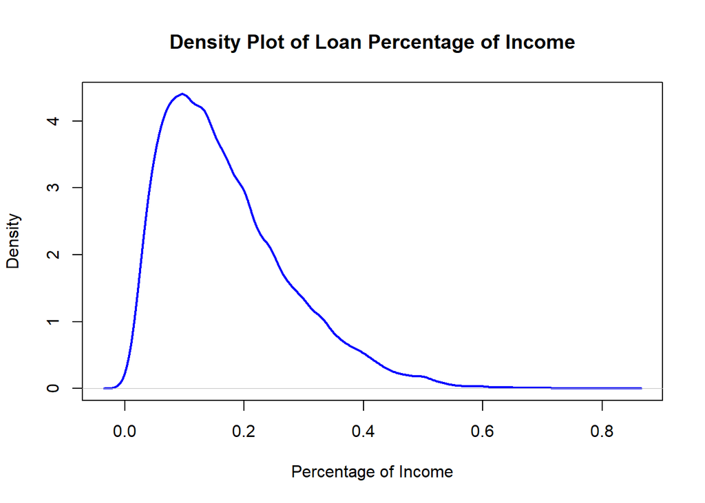

```r
plot(density(credit_risk_dataset$loan_percent_income, na.rm = TRUE), main = "Density Plot of Loan Percentage of Income",
     xlab = "Percentage of Income", ylab = "Density", col = "blue", lwd = 2)
```

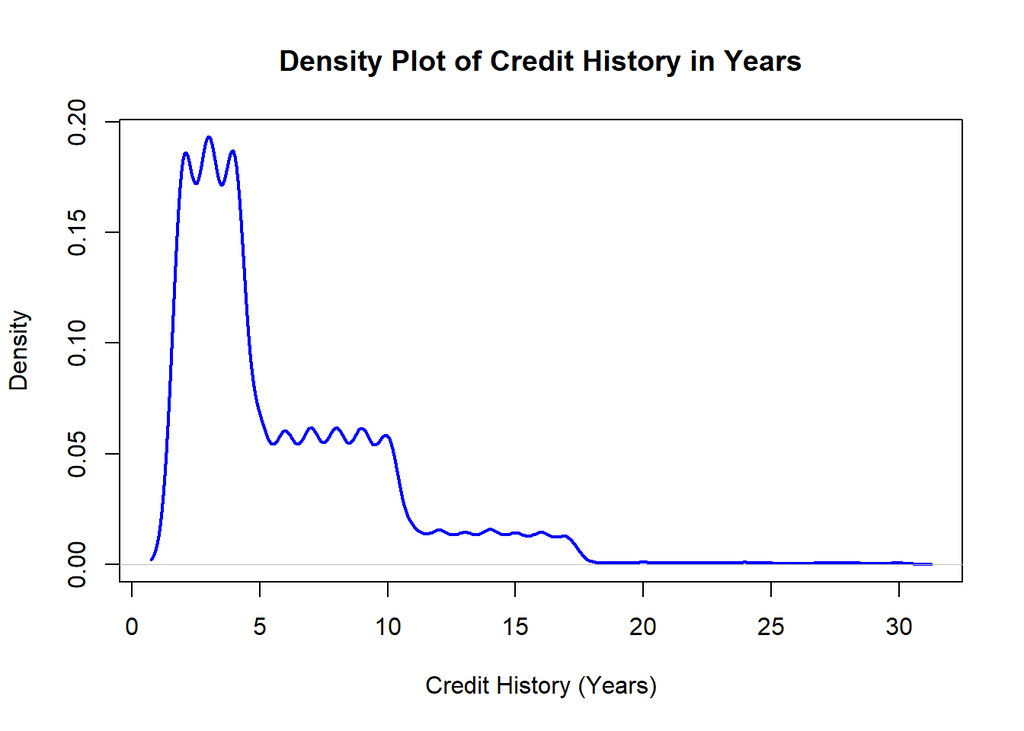

```r
plot(density(credit_risk_dataset$cb_person_cred_hist_length, na.rm = TRUE), main = "Density Plot of Credit History in Years",
     xlab = "Credit History (Years)", ylab = "Density", col = "blue", lwd = 2)
```

Now let’s look at all the categorical variables below:

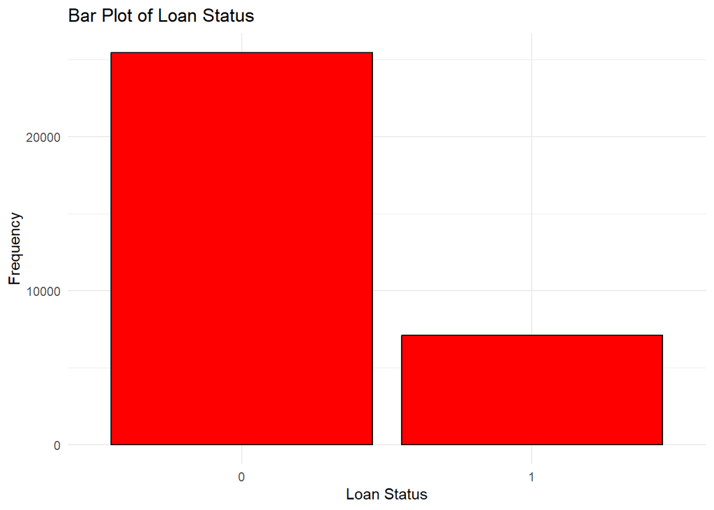

```r
ggplot(credit_risk_dataset, aes(x = loan_status)) +
  geom_bar(fill = "red", color = "black") +
  ggtitle("Bar Plot of Loan Status") +
  xlab("Loan Status") +
  ylab("Frequency") +
  theme_minimal()
```

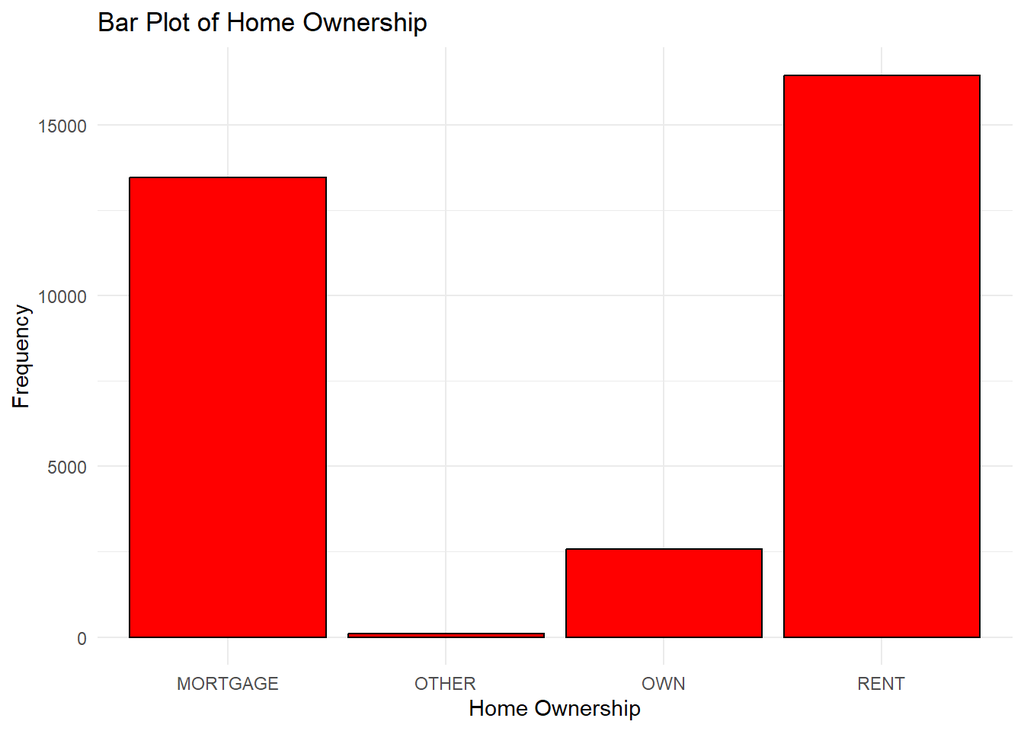

```r
ggplot(credit_risk_dataset, aes(x = person_home_ownership)) +
  geom_bar(fill = "red", color = "black") +
  ggtitle("Bar Plot of Home Ownership") +
  xlab("Home Ownership") +
  ylab("Frequency") +
  theme_minimal()
```

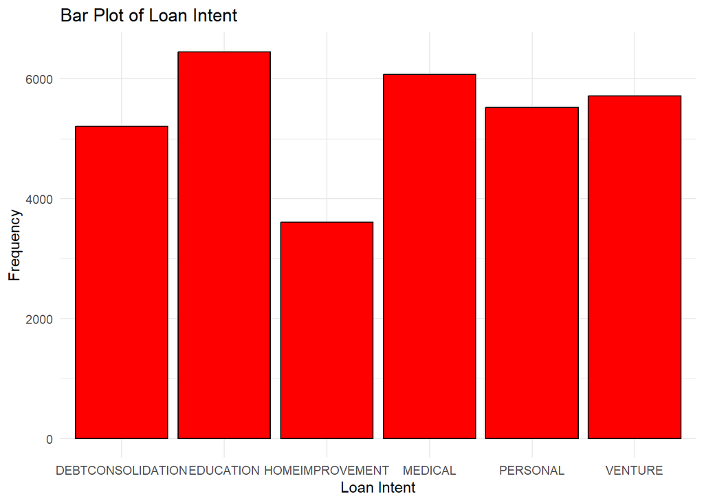

```r
ggplot(credit_risk_dataset, aes(x = loan_intent)) +
  geom_bar(fill = "red", color = "black") +
  ggtitle("Bar Plot of Loan Intent") +
  xlab("Loan Intent") +
  ylab("Frequency") +
  theme_minimal()
```

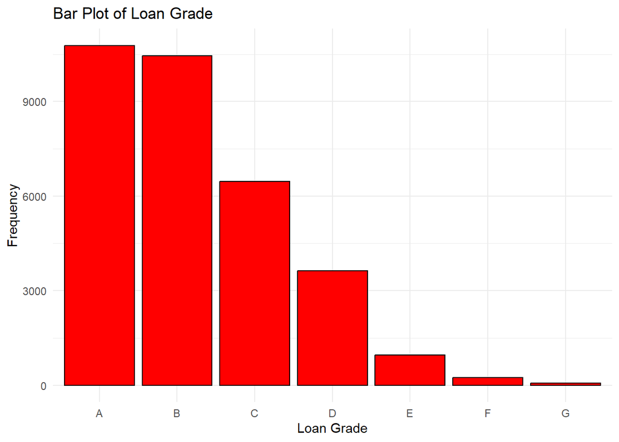

```r
ggplot(credit_risk_dataset, aes(x = loan_grade)) +
  geom_bar(fill = "red", color = "black") +
  ggtitle("Bar Plot of Loan Grade") +
  xlab("Loan Grade") +
  ylab("Frequency") +
  theme_minimal()
```

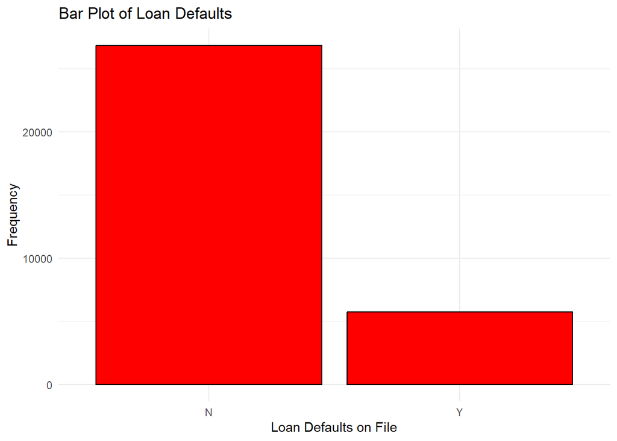

```r
ggplot(credit_risk_dataset, aes(x = cb_person_default_on_file)) +
  geom_bar(fill = "red", color = "black") +
  ggtitle("Bar Plot of Loan Defaults") +
  xlab("Loan Defaults on File") +
  ylab("Frequency") +
  theme_minimal()
```

## 4. Relationship between Features

Now that we have looking the the features individually, we can do some analysis to find insights between the relationships with other features. This insights can provide clarity on what future analysis should focus the attention on. This exploratory analysis will perform three relationship between: 1. two numerical variables 2. two categorical variables 3. one numerical and one categorical variable.

All insights will be explain through visuals and text.

### Bivariate Analysis

First we will explore the relationship between two numerical variables, age and the loan percentage of their income.

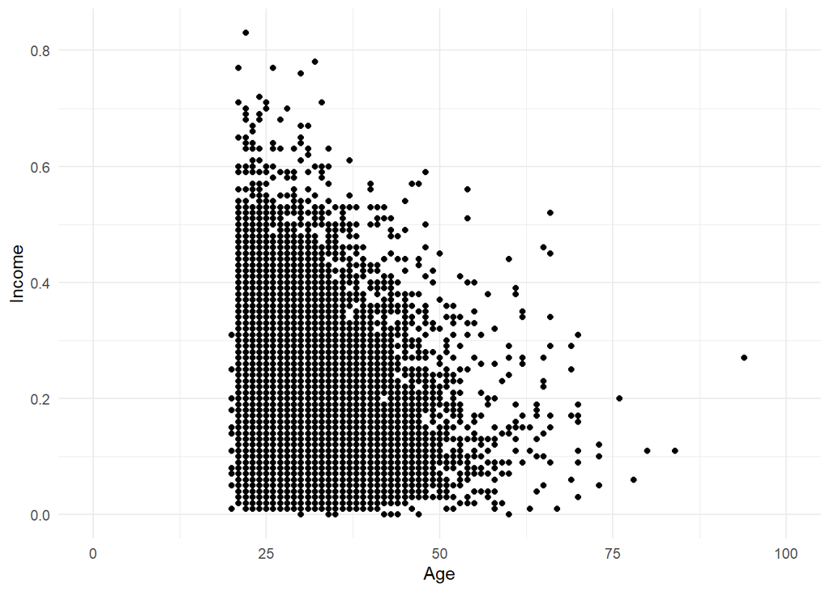

```r
plot1 <- ggplot(credit_risk_dataset, aes(x = person_age, y = loan_percent_income)) +
  geom_point() +
  ylab("Income") +
  xlab("Age") +
  scale_x_continuous(limits = c(0, 100)) +
  theme_minimal()



plot1
```

From this scatterplot, we can clearly see the is a negative correlation between age and loan percentage to income. Younger people tend to have a higher loan percentage of their income compared to older people.

Now looking at two categorical variables we can analyze them visually through a stacked bar plot. Here we will look at the relationship between loan intent and loan grade.

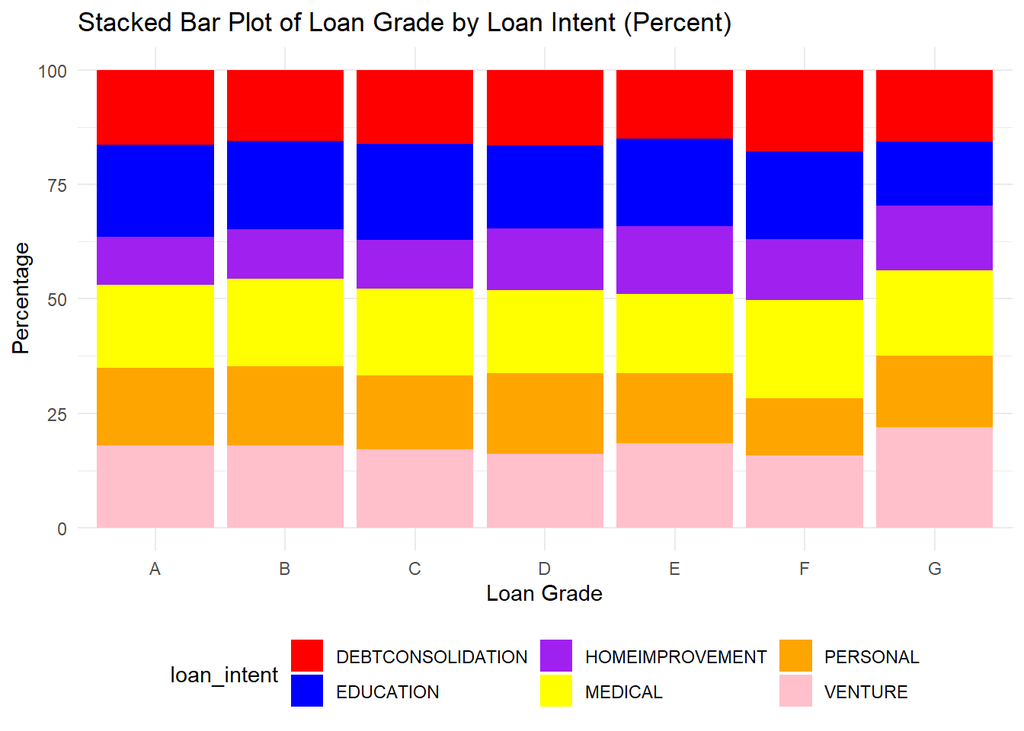

```r
df_percent <- credit_risk_dataset %>%
  group_by(loan_grade, loan_intent) %>%
  summarise(count = n()) %>%
  group_by(loan_grade) %>%
  mutate(percent = count / sum(count) * 100)

# Create the stacked bar plot with percentages
ggplot(df_percent, aes(x = loan_grade, y = percent, fill = loan_intent)) +
  geom_bar(stat = "identity") +
  labs(title = "Stacked Bar Plot of Loan Grade by Loan Intent (Percent)",
       x = "Loan Grade",
       y = "Percentage") +
  scale_fill_manual(values = c("red", "blue", "purple", "yellow", "orange", "pink")) +
  theme_minimal() +
  theme(legend.position = "bottom")
```

From the stacked bar chart and the percentages, we can see thal all intent and loan grades are very similar and there does not seem to be a significant difference.

Finally we will explare the relationship betwee one numerical variable, loan interest rate, with a categoracal veriable, home ownership. This will be explored using boxplots.

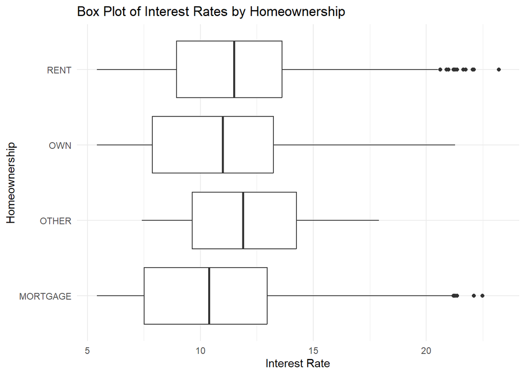

```r
ggplot(credit_risk_dataset, aes(x = loan_int_rate, y = person_home_ownership)) +
  geom_boxplot() +
  labs(title = "Box Plot of Interest Rates by Homeownership",
       x = "Interest Rate",
       y = "Homeownership") +
  theme_minimal()
```

Looking at the different plots, we can see they are all similar except for the “Other” category for Homeownership. This indicates from my persceptive to target younger adults who might live at home. These individuals might be using loans with a low income, which can cause higher interest rates.

## Conclusion

This analysis explored a dataset related to different variables that can explain credit risk for lenders and borrowers. In this analysis we have found missing observations, did univariate analysis, and performed Bivariate analysis.